# Mixed Poisson regression example (Korean dyad data)

Bodo

29/10/2020

Background: This data contains counts of honorific markers for dyadic interactions. Participants were recorded either speaking to a professor or to a friend. The prediction is that the count of honorifics will be higher when speaking to the professor.

We will use Poisson regression to model this, but we have to account for the fact that we have multiple responses from the same participant, namely, one in five ‘tasks’. This requires fitting a random effect of participant.

We will treat ‘task’ here as a random effect. A case could be made for this being a fixed effect, because ‘task’ is repeatable (we could devise a new experiment with the same task) and presumably has a systematic influence on the data. However, there are several reasons for us to treat ‘task’ as random effect here. Specifically, we think of it as a subset of the many different communicative scenarios that suffixes could be used in (we could’ve included many more tasks), and we don’t know in advance which tasks will have higher rates of suffixes or not. So, essentially, we are thinking of this as a sample of communicative scenarios.

The script will proceed to first setup the data, then implement a mixed model analysis with lme4, then show how to perform a likelihood ratio test with afex, finally re-run the analysis in a Bayesian way with brms.

## Prelims

Load packages:

```r
library(tidyverse)
library(lme4) # for mixed models
library(afex) # for likelihood ratio tests (wrapper for lme4)
library(brms) # for Bayesian mixed models
```

R and package versions for reporting and reproducibility:

```r
R.Version()
```

```
## $platform
## [1] "x86_64-apple-darwin17.0"
##
## $arch
## [1] "x86_64"
##
## $os
## [1] "darwin17.0"
##
## $system
## [1] "x86_64, darwin17.0"
##
## $status
## [1] ""
##
## $major
## [1] "4"
##
## $minor
## [1] "0.2"
##
## $year
## [1] "2020"
##
## $month
## [1] "06"
##
## $day
## [1] "22"
##
## $`svn rev`
## [1] "78730"
##
## $language
## [1] "R"
##
## $version.string
## [1] "R version 4.0.2 (2020-06-22)"
##
## $nickname
## [1] "Taking Off Again"
```

```r
packageVersion('tidyverse')
```

```
## [1] '1.3.0'
```

```r
packageVersion('lme4')
```

```
## [1] '1.1.26'
```

```r
packageVersion('afex')
```

```
## [1] '0.28.0'
```

```r
packageVersion('brms')
```

```
## [1] '2.13.3'
```

Load the *honorifics.csv* dataset:

```r
hon <- read_csv('honorifics.csv')
```

Show the data:

```r
hon
```

```
## # A tibble: 28 x 8
##       ID Sex   Condition Movie Tweety RolePlay  Map1  Map2
##    <dbl> <chr> <chr>     <dbl>  <dbl>    <dbl> <dbl> <dbl>
##  1     1 F     friend        1      0        0     4     0
##  2     2 M     friend        0      0        0     0     1
##  3     3 F     friend        0      0        0     7     0
##  4     4 F     friend        0      0        0     0     0
##  5     5 M     friend        0      0        0     0     0
##  6     6 F     friend        0      0        0     0     0
##  7     7 F     friend        0      0        0     0     0
##  8     8 M     friend        8     17        0    27    23
##  9     9 M     friend        0      0        0     0     0
## 10    10 M     friend        0      0        0     0     0
## # … with 18 more rows
```

**Important side note**: This simplified analysis ignores durations. Obviously, for any count variable, it matters how long you are counting for. This can be modeled with an *‘offset()’* term.

## Data processing

This data is wide format, which is non-tidy because the ‘count’ variable is spread across different columns. For tidy data, we want each variable to be one column. So we need to make this data into long format. *pivot_longer()* comes in handy here:

```r
hon <- pivot_longer(hon,
                    cols = Movie:Map2, # columns to make long
                    names_to = 'Task', # name of new task identifier column
                    values_to = 'Count') # name of new response column

# Check:

hon
```

```
## # A tibble: 140 x 5
##       ID Sex   Condition Task     Count
##    <dbl> <chr> <chr>     <chr>    <dbl>
##  1     1 F     friend    Movie        1
##  2     1 F     friend    Tweety       0
##  3     1 F     friend    RolePlay     0
##  4     1 F     friend    Map1         4
##  5     1 F     friend    Map2         0
##  6     2 M     friend    Movie        0
##  7     2 M     friend    Tweety       0
##  8     2 M     friend    RolePlay     0
##  9     2 M     friend    Map1         0
## 10     2 M     friend    Map2         1
## # … with 130 more rows
```

## Mixed model analysis

Let’s create a Poisson model with this data:

```r
hon_mdl <- glmer(Count ~ Condition + # fixed effects
                   (1 + Condition|ID) + (1 + Condition|Task), # random effects
                 data = hon,
                 family = poisson)
```

Notice that we have random slopes for Condition within subjects and Condition within items. This embodies our assumption that different people may respond differently to the politeness manipulation (e.g., some use more honorifics with the professor than others). Fitting a random intercept only model amounts to assuming that all participants behave the same with respect to the politeness condition … which is quite an unreasonable assumption to make in this regard. The same logic carries over to the task item effect.

Check the model:

```r
summary(hon_mdl)
```

```
## Generalized linear mixed model fit by maximum likelihood (Laplace
##   Approximation) [glmerMod]
##  Family: poisson  ( log )
## Formula: Count ~ Condition + (1 + Condition | ID) + (1 + Condition | Task)
##    Data: hon
##
##      AIC      BIC   logLik deviance df.resid
##    563.3    586.8   -273.6    547.3      132
##
## Scaled residuals:
##      Min       1Q   Median       3Q      Max
## -2.49802 -0.41275 -0.04527  0.09484  3.01760
##
## Random effects:
##  Groups Name               Variance Std.Dev. Corr
##  ID     (Intercept)        26.775   5.174
##         Conditionprofessor 25.887   5.088    -1.00
##  Task   (Intercept)         2.370   1.540
##         Conditionprofessor  2.531   1.591    -0.98
## Number of obs: 140, groups:  ID, 14; Task, 5
##
## Fixed effects:
##                    Estimate Std. Error z value Pr(>|z|)
## (Intercept)          -6.561      2.982  -2.201  0.02776 *
## Conditionprofessor    9.212      2.976   3.095  0.00197 **
## ---
## Signif. codes:  0 '***' 0.001 '**' 0.01 '*' 0.05 '.' 0.1 ' ' 1
##
## Correlation of Fixed Effects:
##             (Intr)
## Cndtnprfssr -0.999
```

```r
exp(fixef(hon_mdl)[1]) # friend
```

```
## (Intercept)
## 0.001414135
```

```r
exp(fixef(hon_mdl)[1] + fixef(hon_mdl)[2]) # professor
```

```
## (Intercept)
##    14.16339
```

Let’s explore the random effects structure of the model:

```r
coef(hon_mdl)
```

```
## $ID
##    (Intercept) Conditionprofessor
## 1   -0.8924657           3.593640
## 2   -2.5743096           5.409440
## 3   -0.5421612           3.295975
## 4   -8.2065144          10.647315
## 5   -7.1365997           9.739151
## 6   -8.3951594          10.809074
## 7   -6.3872722           9.121935
## 8    1.8584425           1.035815
## 9  -10.1287821          12.304468
## 10  -4.8612984           8.018493
## 11  -6.8622855           9.510535
## 12  -6.8622855           9.510535
## 13  -6.3343648           9.079395
## 14  -6.8622855           9.510535
##
## $Task
##          (Intercept) Conditionprofessor
## Map1       -4.957226           7.930730
## Map2       -5.416638           7.797911
## Movie      -6.390605           9.333916
## RolePlay   -8.686583          11.376656
## Tweety     -5.759336           7.960153
##
## attr(,"class")
## [1] "coef.mer"
```

The first bit *$ID* tells you each individual’s intercept and slope. The slopes are really interesting to look at. If you happen to have additional information about the participants, for example, it may be interesting to look at the lowest and largest values (participants who made less or more of a difference with respect to the professor condition).

Let’s use afex to perform a likelihood ratio test. This is what I would report as the test in the model (if I was living in an NHST/frequentist world… for the actual publication everything is Bayesian):

```r
hon_afex <- mixed(Count ~ Condition +
                    (1 + Condition|ID) + (1 + Condition|Task),
                  data = hon,
                  family = poisson,
                  method = 'LRT')
```

```
## Contrasts set to contr.sum for the following variables: Condition, Task
```

```
## Fitting 2 (g)lmer() models:
## [..]
```

Check the results:

```r
hon_afex
```

```
## Mixed Model Anova Table (Type 3 tests, LRT-method)
##
## Model: Count ~ Condition + (1 + Condition | ID) + (1 + Condition | Task)
## Data: hon
## Df full model: 8
##      Effect df     Chisq p.value
## 1 Condition  1 14.15 ***   <.001
## ---
## Signif. codes:  0 '***' 0.001 '**' 0.01 '*' 0.05 '+' 0.1 ' ' 1
```

Cool stuff. Remember however that this analysis so far does NOT control for overall duration, for which you would have to include an offset term.

## Same thing Bayesian

Settings forparallel processing (to instruct R to use all cores of my computer):

```r
options(mc.cores=parallel::detectCores())
```

Set weakly informative priors on slope coefficients… this important step obviously requires some thinking, but for now a normal distribution centered at zero with a standard deviation of 2 seems to be a decent choice, and it’ll be more conservative than the corresponding frequentist model anyway.

```r
weak_priors <- c(prior('normal(0, 2)', class = 'b'))
```

(Important side note: In this particular example, none of the other priors are hand-specified. This means that for all other parameters, including random effects parameters, we use brms’s default priors…)

Control parameters for MCMC sampling:

```r
mcmc_controls <- list(adapt_delta = 0.999,
                      max_treedepth = 13)
```

Fit the model. Instead of a Poisson regression, I use negative binomial regression here. For Poisson, the variance is fixed to the mean; negative binomial regression allows the variance to be different.

```r
hon_brm <- brm(Count ~ Condition +
                 (1 + Condition|ID) + (1 + Condition|Task),
               family = 'negbinomial',
               data = hon,

               # Priors:

               prior = weak_priors,

               # Settings for MCMC chain:

               control = mcmc_controls,
               seed = 666, # set seed to a comforting number
               init = 0, chains = 4,
               iter = 6000, warmup = 4000)
```

[output not shown]

Check the model:

```r
summary(hon_brm)
```

```
##  Family: negbinomial
##   Links: mu = log; shape = identity
## Formula: Count ~ Condition + (1 + Condition | ID) + (1 + Condition | Task)
##    Data: hon (Number of observations: 140)
## Samples: 4 chains, each with iter = 6000; warmup = 4000; thin = 1;
##          total post-warmup samples = 8000
##
## Group-Level Effects:
## ~ID (Number of levels: 14)
##                                   Estimate Est.Error l-95% CI u-95% CI Rhat
## sd(Intercept)                         2.66      0.78     1.54     4.60 1.00
## sd(Conditionprofessor)                2.56      0.76     1.46     4.44 1.00
## cor(Intercept,Conditionprofessor)    -0.99      0.01    -1.00    -0.97 1.00
##                                   Bulk_ESS Tail_ESS
## sd(Intercept)                         2863     3959
## sd(Conditionprofessor)                2982     4062
## cor(Intercept,Conditionprofessor)     2774     4589
##
## ~Task (Number of levels: 5)
##                                   Estimate Est.Error l-95% CI u-95% CI Rhat
## sd(Intercept)                         1.71      0.85     0.65     3.89 1.00
## sd(Conditionprofessor)                1.86      0.94     0.70     4.25 1.00
## cor(Intercept,Conditionprofessor)    -0.78      0.27    -0.99     0.04 1.00
##                                   Bulk_ESS Tail_ESS
## sd(Intercept)                         2910     4518
## sd(Conditionprofessor)                2523     4487
## cor(Intercept,Conditionprofessor)     3587     4922
##
## Population-Level Effects:
##                    Estimate Est.Error l-95% CI u-95% CI Rhat Bulk_ESS Tail_ESS
## Intercept             -1.99      1.11    -4.12     0.37 1.00     2835     3833
## Conditionprofessor     4.49      1.14     1.98     6.60 1.00     3411     3626
##
## Family Specific Parameters:
##       Estimate Est.Error l-95% CI u-95% CI Rhat Bulk_ESS Tail_ESS
## shape    37.14     33.59    10.17   125.45 1.00     6617     5699
##
## Samples were drawn using sampling(NUTS). For each parameter, Bulk_ESS
## and Tail_ESS are effective sample size measures, and Rhat is the potential
## scale reduction factor on split chains (at convergence, Rhat = 1).
```

Extract posterior samples:

```r
posts <- posterior_samples(hon_brm)
```

Plot the posterior distribution of the main condition effect:

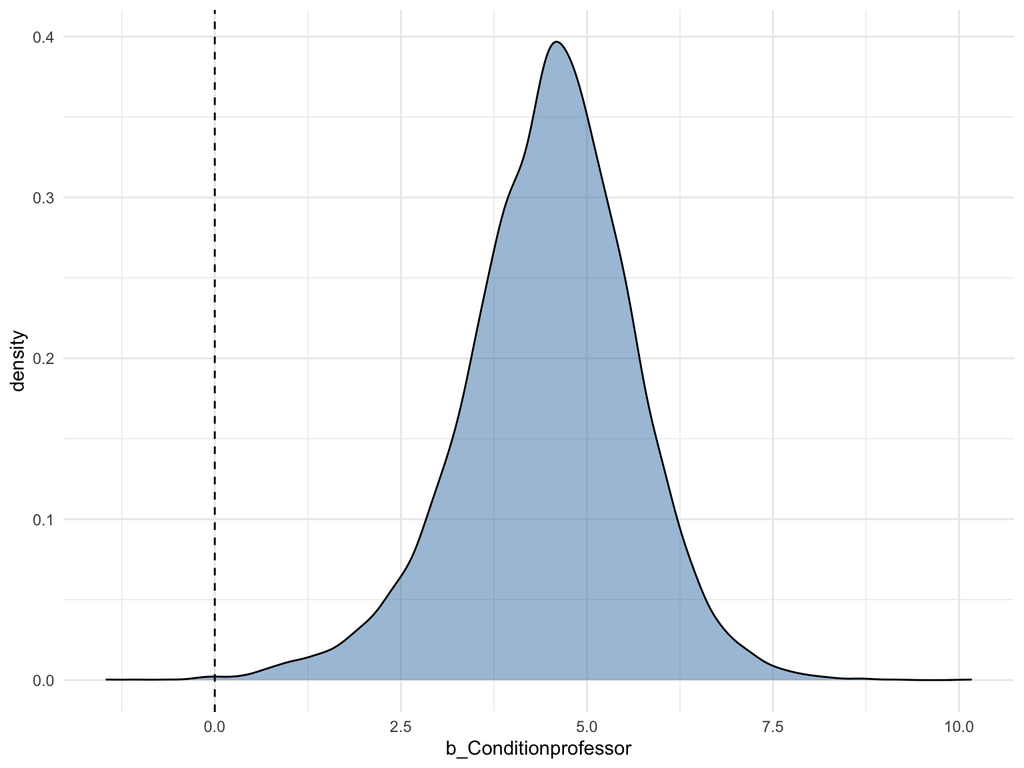

```r
posts %>% ggplot(aes(x = b_Conditionprofessor)) +
  geom_density(fill = 'steelblue', alpha = 0.5, col = 'black') +

  # add line at zero:

  geom_vline(xintercept = 0, lty = 2) +
  theme_minimal()
```

One thing we could report is the posterior probability of the main condition effect being non-zero:

```r
# N of posterior samples above zero:

sum(posts$b_Condition > 0)
```

```
## [1] 7991
```

```r
# Proportion of posterior samples above zero:

sum(posts$b_Condition > 0) / nrow(posts)
```

```
## [1] 0.998875
```

```r
# Estimated posterior probability of the effect being below zero:

1 - sum(posts$b_Condition > 0) / nrow(posts)
```

```
## [1] 0.001125
```

This completes this analysis. Note again that there are a few things I deliberately simplified. In particular, model obviously needs an exposure variable (to account for the fact that counts will invariably be higher for longer trials), and the priors may need some extra thinking. In addition, more assessment of the model quality is needed (e.g., posterior predictive checks).